**CS4132 Data Analytics**

# Fireworks

by Leng Kane Kiat

Important Note: Please keep your report concise and relevant (i.e. show only relevant steps and visualizations used to answer your research questions).

# Table of Content (with relevant hyperlinks to sections)

1. Motivation & Background
2. Summary of Research Questions & Results
3. Dataset
4. Methodology
   - Data Acquisition
     - Source 1
     - Source 2
     - Source 3
     - Source 4
     - Source 5
     - Source 6
     - Source 7
     - Source 8
   - Data Cleaning
     - Cleaning NEISS Injury sampling data
     - Cleaning Google Trends data
   - EDA
   - Results Findings & Conclusion
   - References

# Motivation and Background

Give an overview of the project, motivation, background and goals.

Fireworks are a class of low explosive pyrotechnic devices used for aesthetic and entertainment purposes, commonly as part of a fireworks display/pyrotechnics. Fireworks are often bought during celebrations all around the world. However, fireworks can also cause injuries and fires. I would like to analyze the trend of the popularity of fireworks, as well as whether or not COVID-19 has affected this demand, as well as the frequency of injuries over the years.

# Summary of Research Questions & Results

Repeat your research questions in a numbered list. After each research question, clearly state the answer/conclusion you determined. Do not give details or justifications yet — just the answer

1. **Has the popularity of fireworks increased or decreased over time?** Increased
2. **When in the year are fireworks most popular?** 4th of July, Deepavali, New Years Day
   - When in the year are firework injuries most common?
3. **Has the rate of fireworks injuries increased or decreased over time?** Not statistically significant
4. **Breaking down Fireworks-Related Injuries**
   - by Age
   - by Sex
   - by Race
   - by Body Part injured
5. **Has the pandemic affected sales of fireworks and injury rate of fireworks as professional events were cancelled?**

# Dataset

Numbered list of dataset (with downloadable links) and a brief but clear description of each dataset used. Draw reference to the numbering when describing methodology (data cleaning and analysis).

     https://www2.census.gov/programs-surveys/popest/tables/2010-2019/national/asrh/nc-est2019-asr6h.xlsx
   - `2020-2021` https://www2.census.gov/programs-surveys/popest/tables/2020-2021/state/totals/NST-EST2021-POP.xlsx

     https://www2.census.gov/programs-surveys/popest/tables/2020-2021/national/asrh/nc-est2021-asr6h.xlsx
4. https://www.cpsc.gov/cgibin/NEISSQuery/home.aspx Injury statistics in the USA, one of the sources for the above report
5. https://www.trademap.org/ Accessing International trade data. Find import/exports for product code `360410`
6. https://dataweb.usitc.gov/ This is the portal for accessing USA imports and exports of goods. I made an account and made the following request:
   - **Step 1: Trade Flow and Classification System**
     - Trade Flow : Imports For Consumption
     - Classification System HTS Items
   - **Step 2: Data and Years**
     - Data To Report : Customs Value, First Unit of Quantity, Second Unit of Quantity
     - Data Format : 1
     - Years 1989-2022
     - Timeframe Aggregation Annual
   - **Step 3: Countries**
     - Select Type : Use All Countries
     - Country Aggregation : Aggregate countries
   - **Step 4: Commodities**
     - Select Type : Select Individual Commodities
     - Commodity List : 360410
     - Commodity Aggregation : Level 6
     - Commodity Aggregation : Aggregate Commodities
     - Description Display : NO
   - **Step 5: Programs**
     - Select Type : Use All Programs
     - Import Program Aggregation : Aggregate CSC
   - **Step 6: Rate Provision Codes**
     - Select Type : Use All Provision Codes
     - Provision Code Aggregation : Aggregate RPCODE
   - **Step 7: Districts**
     - Select Type : Use All Districts
     - District Aggregation : Aggregate District
   - **Step 8: Report Layout**
     - Column Order : UNITS
     - Percent Change Column : Unchecked
     - Show All : Checked
     - Enable Subtotals : Unchecked
7. https://trends.google.com/trends/explore?q=firework Google Trends data for fireworks
8. CPSC (U.S. Consumer Product Safety Commission)'s annual fireworks report. Estimated Injuries were parsed from their tables for years 2003, 2019 and 2021.

   Here are the links to those pdfs that were used:
   - https://www.cpsc.gov/s3fs-public/pdfs/2003fwreport.PDF
   - https://www.cpsc.gov/s3fs-public/2019-Fireworks-Annual-Report.pdf
   - https://www.cpsc.gov/s3fs-public/2021-Fireworks-Annual-Report.pdf

   These were [scraped](https://gist.github.com/hemisemidemipresent/38baeff3432f64480f2f6b7a02500c07) into `firework_estimated_injuries.csv`

# Methodology

```python
# Utility
import math
# Core
import numpy as np
import pandas as pd
# Scraping
import requests
from bs4 import BeautifulSoup
# Data Visualization
import matplotlib.pyplot as plt
import seaborn as sns
# Data Modelling
from scipy import stats
from sklearn.linear_model import LinearRegression
from sklearn.model_selection import train_test_split
```

## Data Acquisition

Code for scraping pdfs into csvs are not here, instead there are hyperlinks on relevant code snippets that has the pdf-scraping code For each dataset, a brief overview of the data it contains has been given, and the meaning of relevant columns explained.

### Sources 1 and 2 - fireworks revenue (USA)

this data was already scraped from the pdf ([code](https://gist.github.com/hemisemidemipresent/9fd30a427bc3a6983e9714612fd19c05)) and combined into this `.csv` file

```python
revenue = pd.read_csv("fireworks_revenue.csv")
revenue = revenue[["year", "display fireworks revenue","consumer fireworks revenue"]]
revenue.head()
```

|  | year | display fireworks revenue | consumer fireworks revenue |
| --- | --- | --- | --- |
| 0 | 1998 | 141000000.0 | 284000000.0 |
| 1 | 1999 | 167000000.0 | 333000000.0 |
| 2 | 2000 | 203000000.0 | 407000000.0 |
| 3 | 2001 | 217000000.0 | 433000000.0 |
| 4 | 2002 | 242000000.0 | 483000000.0 |

### Source 3 - USA population over time

one thing that I have learnt from this, it is that standards, file types, etc change with time, so there will not be much purpose doing this fully automatically especially when there's a new data format in the next 10-20 years.

We first combine 2000-2021 data for total, race, age and sex

```python
age_cols = ["Under 5","5-9","10-14","15-19","20-24","25-29","30-34","35-39",'40-44','45-49','50-54','55-59','60-64','65-69','70-74','75-79','80-84','85 and over']
age_cols_2000 = age_cols[:-1] + ['85-89','90-94','95-99','100 and over']
sex_cols = ['male','female']
race_cols = ['White','Black','AIAN','Asian','NHPI','Two or More Races']

# 2000-2009
us_pop_2000 = pd.read_csv("us_pop_2000-2009.csv").replace({',':''},regex=True)
t2000_2009 = us_pop_2000[3:25]
us_sex_2000 = us_pop_2000.iloc[[42,81]]

t2000_2009 = pd.concat([t2000_2009,us_sex_2000])

t2000_2009.columns = range(1998,2012)
t2000_2009 = t2000_2009[range(2000,2010)]
t2000_2009 = t2000_2009.T.apply(pd.to_numeric)
t2000_2009.columns = ["total"] + age_cols_2000 + sex_cols
t2000_2009["85 and over"] = t2000_2009['85-89'] + t2000_2009['90-94'] + t2000_2009['95-99'] + t2000_2009['100 and over']
t2000_2009 = t2000_2009[['total'] + age_cols + sex_cols]

us_pop_2000_r = pd.read_csv("us_pop_2000-2009_by_race.csv")[3:].replace({',':''},regex=True)
us_pop_2000_r.columns = range(1998,2012)
us_pop_2000_r = us_pop_2000_r[range(2000,2010)].iloc[2:8].T.apply(pd.to_numeric)
us_pop_2000_r.columns = race_cols
t2000_2009 = t2000_2009.merge(us_pop_2000_r, left_index=True, right_index=True)

# 2010-2019
us_pop_2010 = pd.read_excel('us_pop_2010-2019.xlsx', engine='openpyxl')[4:]
t2010_2019 = us_pop_2010[:19]
us_sex_2010 = us_pop_2010.iloc[[36,72]]

t2010_2019 = pd.concat([t2010_2019,us_sex_2010])

t2010_2019.columns = range(2007,2020)
t2010_2019 = t2010_2019[range(2010,2020)].T
t2010_2019.columns = ['total'] + age_cols + sex_cols


for race in race_cols:
    us_pop_2010_r = pd.read_excel('us_pop_2010-2019.xlsx', engine='openpyxl', sheet_name=race).iloc[[4]]
    us_pop_2010_r.columns = range(2007,2020)
    us_pop_2010_r = us_pop_2010_r[range(2010,2020)].T
    us_pop_2010_r.columns = [race]
    t2010_2019 = t2010_2019.merge(us_pop_2010_r, left_index=True, right_index=True)

# 2020-2021
us_pop_2020 = pd.read_excel('us_pop_2020-2021.xlsx', engine='openpyxl')[3:]
t2020_2021 = us_pop_2020[:19]
us_sex_2020 = us_pop_2020.iloc[[36,72]]

t2020_2021 = pd.concat([t2020_2021, us_sex_2020])

t2020_2021.columns = range(2018,2022)
t2020_2021 = t2020_2021[range(2020,2022)].T
t2020_2021.columns = ['total'] + age_cols + sex_cols

for race in race_cols:
    us_pop_2020_r = pd.read_excel('us_pop_2020-2021.xlsx', engine='openpyxl', sheet_name=race).iloc[[4]]
    us_pop_2020_r.columns = range(2018,2022)
    us_pop_2020_r = us_pop_2020_r[range(2020,2022)].T
    us_pop_2020_r.columns = [race]
    t2020_2021 = t2020_2021.merge(us_pop_2020_r, left_index=True, right_index=True)

t2000_2021 = pd.concat([t2000_2009, t2010_2019, t2020_2021]).astype(int)
t2000_2021.tail()
```

|  | total | Under 5 | 5-9 | 10-14 | 15-19 | 20-24 | 25-29 | 30-34 | 35-39 | 40-44 | ... | 80-84 | 85 and over | male | female | White | Black | AIAN | Asian | NHPI | Two or More Races |
| --- | --- | --- | --- | --- | --- | --- | --- | --- | --- | --- | --- | --- | --- | --- | --- | --- | --- | --- | --- | --- | --- |
| 2017 | 324985539 | 19890972 | 20309346 | 20767794 | 21094597 | 22042321 | 23328936 | 21934476 | 21180305 | 19576279 | ... | 5959281 | 6467173 | 160045920 | 164939619 | 249270773 | 43374142 | 4101605 | 18764237 | 780316 | 8694466 |
| 2018 | 326687501 | 19762962 | 20188285 | 20868629 | 21064661 | 21808086 | 23510961 | 22099149 | 21532022 | 19681452 | ... | 6123781 | 6544300 | 160885734 | 165801767 | 249961025 | 43732024 | 4145811 | 19134105 | 793787 | 8920749 |
| 2019 | 328239523 | 19576683 | 20195895 | 20798268 | 21054570 | 21632940 | 23509016 | 22431305 | 21737521 | 19921623 | ... | 6317207 | 6604958 | 161657324 | 166582199 | 250522190 | 44075086 | 4188092 | 19504862 | 806937 | 9142356 |
| 2020 | 331501080 | 19281212 | 20336862 | 21682996 | 21530899 | 21468060 | 22805201 | 22877649 | 22233088 | 20670322 | ... | 6155000 | 6020152 | 164214877 | 167286203 | 251741953 | 44861705 | 4322700 | 20149350 | 850297 | 9575075 |
| 2021 | 331893745 | 18827338 | 20291548 | 21447784 | 21564666 | 21523997 | 22392477 | 23102628 | 22299318 | 21104536 | ... | 6301306 | 5975756 | 164384742 | 167509003 | 251461611 | 45060857 | 4367540 | 20350483 | 863043 | 9790211 |

5 rows × 27 columns

We can find the total population statistics for 1980-2021:

```python
# read text files and parse them
data = requests.get("https://www2.census.gov/programs-surveys/popest/tables/1980-1990/state/asrh/8090com.txt").content
soup =  BeautifulSoup(data, "lxml")
text = soup.find("p").text
text = text.split('\n')[23]
t1980_1989 = text.replace("\r",'')[14:-10]

data = requests.get("https://www2.census.gov/programs-surveys/popest/tables/1990-2000/state/totals/st-99-07.txt").content
soup =  BeautifulSoup(data, "lxml")
text = soup.find("p").text
text = text.split('\n')[14]
t1990_1999 = text.replace("\r",'')[38:-10]

t1980_1989 = t1980_1989.split(" ")

t1990_1999 = t1990_1999.split(" ")
t1990_1999.reverse() # reversed order

t1980_2021 = pd.DataFrame(data=[t1980_1989 + t1990_1999 + t2000_2021["total"].to_list()])
t1980_2021.columns = range(1980,2022)
t1980_2021 = t1980_2021.T.reset_index().apply(pd.to_numeric)
t1980_2021.columns = ['year','us_population']
t1980_2021.tail()
```

|  | year | us_population |
| --- | --- | --- |
| 37 | 2017 | 324985539 |
| 38 | 2018 | 326687501 |
| 39 | 2019 | 328239523 |
| 40 | 2020 | 331501080 |
| 41 | 2021 | 331893745 |

### Source 4: NEISS

This is a **sample** of all the injuries from hospitals in the United States

There are many such data files; one for each year, but only one has been shown

More information for the columns has be found [here](https://www.cpsc.gov/s3fs-public/2019_NEISS_Coding_Manual.pdf)

some of the tsv files do not seem to be able to be parsed - the encoding was manually changed to utf-8

```python
pd.read_csv('neiss2021.tsv', sep='\t').head() # year range is 2002-2021
```

|  | CPSC_Case_Number | Treatment_Date | Age | Sex | Race | Other_Race | Hispanic | Body_Part | Diagnosis | Other_Diagnosis | ... | Fire_Involvement | Product_1 | Product_2 | Product_3 | Alcohol | Drug | Narrative_1 | Stratum | PSU | Weight |
| --- | --- | --- | --- | --- | --- | --- | --- | --- | --- | --- | --- | --- | --- | --- | --- | --- | --- | --- | --- | --- | --- |
| 0 | 210102715 | 01/01/2021 | 38 | 2 | 2 | NaN | 2 | 31 | 71 | BACK PAIN | ... | 0 | 4056 | 0 | 0 | 0 | 0 | 38YOF REACHED FOR OBJECT OFF SHELF, DEVELOPED ... | V | 25 | 15.4438 |
| 1 | 210102719 | 01/01/2021 | 65 | 1 | 4 | NaN | 2 | 34 | 57 | NaN | ... | 0 | 1842 | 0 | 0 | 0 | 0 | 65YOM MISSED STEP WHILE GOING UP STAIRS AND FE... | V | 25 | 15.4438 |
| 2 | 210102730 | 01/01/2021 | 32 | 2 | 2 | NaN | 2 | 79 | 71 | ABDOMINAL PAIN | ... | 0 | 604 | 0 | 0 | 0 | 0 | 32YOF WAS PUSHING DRESSER, PT 7-8 WKS PREGNANT... | V | 25 | 15.4438 |
| 3 | 210102742 | 01/02/2021 | 42 | 2 | 2 | NaN | 2 | 75 | 62 | NaN | ... | 0 | 1842 | 0 | 0 | 0 | 0 | 42YOF SLIPPED AND FELL ON ICE WHILE WALKING DO... | V | 25 | 15.4438 |
| 4 | 210102743 | 01/02/2021 | 22 | 2 | 1 | NaN | 1 | 35 | 64 | NaN | ... | 0 | 3283 | 0 | 0 | 0 | 0 | 22YOF WAS SKIING, WHILE WALKING BACK TO TAKE O... | V | 25 | 15.4438 |

5 rows × 25 columns

### Source 5: https://www.trademap.org - got data specifically for the fireworks

```python
firework_imports = pd.read_csv('Firework_list_of_importers.tsv', sep='\t')
firework_imports = firework_imports.T
firework_imports.columns = firework_imports.iloc[0]
firework_imports = firework_imports[1:-1].reset_index()
firework_imports["index"] = firework_imports["index"].str.replace("Imported value in ","")
firework_imports = firework_imports.rename(columns={"index":"year"})
firework_imports = firework_imports.apply(pd.to_numeric)

firework_imports.head()
```

| Importers | year | World | United States of America | United Kingdom | Germany | Denmark | Poland | Japan | Netherlands | Indonesia | ... | Saint Helena | Saint Lucia | Saint Pierre and Miquelon | Tuvalu | United States Minor Outlying Islands | Free Zones | Tonga | Syrian Arab Republic | Sudan | Sudan (before 2012) |
| --- | --- | --- | --- | --- | --- | --- | --- | --- | --- | --- | --- | --- | --- | --- | --- | --- | --- | --- | --- | --- | --- |
| 0 | 2002 | 430770.0 | 161331.0 | 28584.0 | 52198.0 | 9341.0 | 4060.0 | 34998.0 | 19395.0 | 603.0 | ... | 1.0 | 21.0 | 4.0 | 0.0 | NaN | NaN | 0.0 | 0.0 | NaN | 37.0 |
| 1 | 2003 | 488972.0 | 196870.0 | 43872.0 | 48647.0 | 11463.0 | 4270.0 | 31849.0 | 25266.0 | 147.0 | ... | NaN | 10.0 | NaN | 15.0 | NaN | NaN | 0.0 | 0.0 | NaN | 19.0 |
| 2 | 2004 | 551808.0 | 209181.0 | 33219.0 | 76071.0 | 17426.0 | 10039.0 | 32285.0 | 22407.0 | 414.0 | ... | NaN | 14.0 | NaN | NaN | NaN | 1.0 | NaN | 0.0 | NaN | 127.0 |
| 3 | 2005 | 582330.0 | 258395.0 | 36923.0 | 60551.0 | 7906.0 | 7819.0 | 31534.0 | 4.0 | 1742.0 | ... | NaN | 8.0 | 1.0 | 4.0 | NaN | NaN | NaN | 0.0 | NaN | 8.0 |
| 4 | 2006 | 652408.0 | 264601.0 | 34002.0 | 71952.0 | 10597.0 | 8061.0 | 30249.0 | 27935.0 | 1633.0 | ... | NaN | 30.0 | NaN | NaN | NaN | NaN | NaN | 28.0 | NaN | 19.0 |

5 rows × 223 columns

```python
firework_exports = pd.read_csv('Firework_list_of_exporters.tsv', sep='\t')
firework_exports = firework_exports.T
firework_exports.columns = firework_exports.iloc[0]
firework_exports = firework_exports[1:-1].reset_index()
firework_exports["index"] = firework_exports["index"].str.replace("Exported value in ","")
firework_exports = firework_exports.rename(columns={"index":"year"})
firework_exports = firework_exports.apply(pd.to_numeric)

firework_exports.head()
```

| Exporters | year | World | France | Germany | United States of America | Israel | Czech Republic | Sweden | Singapore | Italy | ... | Northern Mariana Islands | Papua New Guinea | Free Zones | United States Minor Outlying Islands | Uganda | United Arab Emirates | Syrian Arab Republic | Rwanda | Saint Lucia | Qatar |
| --- | --- | --- | --- | --- | --- | --- | --- | --- | --- | --- | --- | --- | --- | --- | --- | --- | --- | --- | --- | --- | --- |
| 0 | 2002 | 83710.0 | 1133.0 | 25813.0 | 22904.0 | 597.0 | 1764.0 | 4082.0 | 3307.0 | 1135.0 | ... | NaN | 0.0 | NaN | 1.0 | 0.0 | NaN | 0.0 | 0.0 | 0.0 | 1.0 |
| 1 | 2003 | 97576.0 | 18422.0 | 27742.0 | 15711.0 | 820.0 | 1942.0 | 4713.0 | 1766.0 | 1164.0 | ... | NaN | 0.0 | NaN | NaN | 0.0 | NaN | 0.0 | 0.0 | 0.0 | 0.0 |
| 2 | 2004 | 112884.0 | 9137.0 | 40323.0 | 21968.0 | 424.0 | 2161.0 | 5790.0 | 2831.0 | 2160.0 | ... | 7.0 | 0.0 | NaN | 4.0 | 0.0 | NaN | 0.0 | 0.0 | 0.0 | 0.0 |
| 3 | 2005 | 105150.0 | 14305.0 | 35480.0 | 22443.0 | 0.0 | 1727.0 | 6326.0 | 2926.0 | 1976.0 | ... | 8.0 | NaN | NaN | 1.0 | 0.0 | 54.0 | 0.0 | 0.0 | 0.0 | 0.0 |
| 4 | 2006 | 130961.0 | 21102.0 | 49463.0 | 17985.0 | 1359.0 | 1986.0 | 7445.0 | 5131.0 | 2099.0 | ... | NaN | NaN | NaN | 18.0 | 0.0 | NaN | 30.0 | 0.0 | 0.0 | 0.0 |

5 rows × 151 columns

### Source 6 - firework imports (USA)

There are 2 different tables here, one by weight (kg) and one by value (USD).

```python
df = pd.read_excel('firework_imports_usa.xlsx',engine='openpyxl', sheet_name="Customs Value", skiprows=0)
df = df.T
df.columns=df.iloc[0]
imports_usa = df[3:]
imports_usa = imports_usa.reset_index()
imports_usa["index"] = imports_usa["index"].str.replace("Year ","")
imports_usa.columns = ["year","Customs Value","Total"]
imports_usa = imports_usa[["year","Customs Value"]].apply(pd.to_numeric) # drop Total column since it is identical to the Customs Value column
imports_usa.head()
```

|  | year | Customs Value |
| --- | --- | --- |
| 0 | 1989 | 68889320 |
| 1 | 1990 | 61410160 |
| 2 | 1991 | 69039815 |
| 3 | 1992 | 79098085 |
| 4 | 1993 | 78449752 |

```python
df = pd.read_excel('firework_imports_usa.xlsx',engine='openpyxl', sheet_name="First Unit of Quantity", skiprows=0)
df = df.T
df.columns=df.iloc[0]
imports_usa_kg = df[3:]
imports_usa_kg = imports_usa_kg.reset_index()
imports_usa_kg["index"] = imports_usa_kg["index"].str.replace("Year ","")
imports_usa_kg.columns = ["year","weight","Total"]
imports_usa_kg = imports_usa_kg[["year","weight"]].apply(pd.to_numeric) # drop Total column since it is identical to the Customs Value column
imports_usa_kg.head()
```

|  | year | weight |
| --- | --- | --- |
| 0 | 1989 | 33400613 |
| 1 | 1990 | 27390153 |
| 2 | 1991 | 30397190 |
| 3 | 1992 | 36561814 |
| 4 | 1993 | 43196243 |

### Source 7 - Google Trends

I got data (Worldwide) for each year, since that allows you to get the data by the week rather than by the month

```python
pd.read_csv("firework2021.csv").head() # will be cleaned later
```

|  | Category: All categories |
| --- | --- |
| Week | firework: (Worldwide) |
| 2021-01-03 | 10 |
| 2021-01-10 | 6 |
| 2021-01-17 | 12 |
| 2021-01-24 | 7 |

### Source 8 - CPSC Annual Firework Reports

```python
firework_estimated_injuries = pd.read_csv("firework_estimated_injuries.csv")
firework_estimated_injuries.head()
```

|  | Year | Estimated Injuries |
| --- | --- | --- |
| 0 | 1991 | 10900 |
| 1 | 1992 | 12500 |
| 2 | 1993 | 12100 |
| 3 | 1994 | 12500 |
| 4 | 1995 | 10900 |

## Data Cleaning

For data cleaning, be clear in which dataset (or variables) are used, what has been done for missing data, how was merging performed, explanation of data transformation (if any). If data is calculated or summarized from the raw dataset, explain the rationale and steps clearly.

### Cleaning NEISS Injury sampling data

Many of the original csvs had random newlines inserted into the data, those were found with [some code](https://gist.github.com/hemisemidemipresent/21a2a184718c5eea3d3ae5a651d2873b) and were manually removed

We first preliminarily filter reports to those that only include 'FIREWORK' and 'FIRE WORK', or those which have a Product ID have 1313 (Fireworks)

```python
# filter NEISS data for only fireworks
dtypes = {
        "CPSC_Case_Number": "Int64",
        "Age": "Int64",
        "Sex": "Int64",
        "Race": "Int64",
        "Other_Race": "string",
        "Hispanic": "Int64",
        "Body_Part": "Int64",
        "Diagnosis": "Int64",
        "Other_Diagnosis": "string",
        "Body_Part_2": "Int64",
        "Diagnosis_2": "Int64",
        "Other_Diagnosis_2": "string",
        "Disposition": "Int64",
        "Location": "Int64",
        "Fire_Involvement": "Int64",
        "Product_1": "Int64",
        "Product_2": "Int64",
        "Product_3": "Int64",
        "Alcohol": "Int64",
        "Drug": "Int64",
        "Narrative": "string",
        "Stratum": "string",
        "PSU": "Int64",
        "Weight": "float64"
}
NEISS_df = None
start = 2002
end = 2021
for i in range(start,end+1):
    print(f'opening {i}')
    df = pd.read_csv(f'neiss{i}.tsv', sep='\t', dtype=dtypes, parse_dates=["Treatment_Date"])
    if i>=2020:
        df = df.rename(columns={"Narrative_1":"Narrative"})
    # choose all fireworks
    df = df.loc[(df.Narrative.str.count('FIREWORK')>0) | (df.Narrative.str.count('FIRE WORK')>0) | (df.Product_1==1313) | (df.Product_2==1313) | (df.Product_3==1313)].copy()
    # remove all firecrackers
    df = df.loc[(df.Narrative.str.count('FIRE CRACK')==0) & (df.Narrative.str.count('FIRECRACK')==0)]
    df.loc[:, "year"] = i
    if i == start:
        NEISS_df = df
    else:
        NEISS_df = pd.concat([NEISS_df, df])
NEISS_df = NEISS_df.reset_index(drop=True)

# for future storage so that this massive codeblock doesnt have to run everytime:
NEISS_df.to_csv('neiss.csv')
```

```
opening 2002
opening 2003
opening 2004
opening 2005
opening 2006
opening 2007
opening 2008
opening 2009
opening 2010
opening 2011
opening 2012
opening 2013
opening 2014
opening 2015
opening 2016
opening 2017
opening 2018
opening 2019
opening 2020
opening 2021
```

```python
# for future retrieval
NEISS_df = pd.read_csv('neiss.csv', dtype=dtypes, parse_dates=["Treatment_Date"])
NEISS_df
```

|  | Unnamed: 0 | CPSC_Case_Number | Treatment_Date | Age | Sex | Race | Other_Race | Hispanic | Body_Part | Diagnosis | ... | Product_1 | Product_2 | Product_3 | Alcohol | Drug | Narrative | Stratum | PSU | Weight | year |
| --- | --- | --- | --- | --- | --- | --- | --- | --- | --- | --- | --- | --- | --- | --- | --- | --- | --- | --- | --- | --- | --- |
| 0 | 0 | 20104136 | 2002-01-01 | 36 | 1 | 1 | <NA> | <NA> | 77 | 53 | ... | 1313 | 0 | 0 | <NA> | <NA> | PATIENT WAS STRUCK IN THE EYE WITH A ROMAN CAN... | V | 64 | 15.0084 | 2002 |
| 1 | 1 | 20105038 | 2002-01-01 | 34 | 2 | 1 | <NA> | <NA> | 77 | 53 | ... | 1313 | 0 | 0 | <NA> | <NA> | PT WAS SETTING OFF FIREWORKS AT HOME WHEN ONE ... | S | 28 | 68.8791 | 2002 |
| 2 | 2 | 20106188 | 2002-01-01 | 23 | 2 | 2 | <NA> | <NA> | 77 | 53 | ... | 1313 | 0 | 0 | <NA> | <NA> | 23 YOF HURT FROM FIREWORKS INJURY TO EYE.DX: C... | S | 71 | 68.8791 | 2002 |
| 3 | 3 | 20106700 | 2002-01-01 | 9 | 1 | 1 | <NA> | <NA> | 77 | 53 | ... | 1313 | 0 | 0 | <NA> | <NA> | PT WAS HIT IN THE EYE WITH A BOTTLE ROCKET. | C | 32 | 5.9567 | 2002 |
| 4 | 4 | 20107479 | 2002-01-01 | 15 | 1 | 2 | <NA> | <NA> | 77 | 59 | ... | 1313 | 0 | 0 | <NA> | <NA> | 15 Y.O. B MALE W/CORNEAL LAC. PT WAS SHOOTING ... | V | 22 | 15.0084 | 2002 |
| ... | ... | ... | ... | ... | ... | ... | ... | ... | ... | ... | ... | ... | ... | ... | ... | ... | ... | ... | ... | ... | ... |
| 4640 | 4640 | 220221833 | 2021-07-04 | 30 | 1 | 2 | <NA> | 2 | 76 | 59 | ... | 1313 | 0 | 0 | 0 | 0 | 30YOM PRESENTS AFTER FIREWORK, TYPE R, EXPLODE... | V | 40 | 17.0695 | 2021 |
| 4641 | 4641 | 220221836 | 2021-07-04 | 27 | 1 | 0 | <NA> | 1 | 77 | 71 | ... | 1313 | 0 | 0 | 0 | 0 | 27YOM PRESENTS WITH EYE IRRITATION AFTER FIREW... | V | 40 | 17.0695 | 2021 |
| 4642 | 4642 | 220223106 | 2021-07-06 | 15 | 1 | 1 | <NA> | 1 | 82 | 51 | ... | 1313 | 0 | 0 | 0 | 0 | 15YOM PRESENTS WITH BLAST INJURY TO BILATERAL ... | V | 40 | 17.0695 | 2021 |
| 4643 | 4643 | 220225313 | 2021-07-08 | 5 | 1 | 3 | UNKNOWN | 1 | 33 | 51 | ... | 1313 | 0 | 0 | 0 | 0 | 5YOM WITH BURN TO RIGHT FOREARM FROM TYPE P FI... | V | 40 | 17.0695 | 2021 |
| 4644 | 4644 | 220231585 | 2021-07-13 | 34 | 2 | 5 | <NA> | 2 | 82 | 51 | ... | 1313 | 0 | 0 | 0 | 0 | 34YOF WAS DISTRACTED AND A SPARKLER (TYPE L) H... | V | 40 | 17.0695 | 2021 |

4645 rows × 27 columns

### Cleaning Google Trends data

```python
google_trends = None
for i in range(2004,2022):
    df = pd.read_csv(f"firework{i}.csv")
    df = df.reset_index()
    df.columns = ["week", "firework"]
    df = df[1:]
    if i == 2004:
        google_trends = df
    else:
        google_trends = pd.concat([google_trends, df])
google_trends.week = pd.to_datetime(google_trends.week)
google_trends.firework = pd.to_numeric(google_trends.firework)
google_trends.columns = ["date", "firework"]
google_trends.head()
```

|  | date | firework |
| --- | --- | --- |
| 1 | 2004-01-04 | 6 |
| 2 | 2004-01-11 | 7 |
| 3 | 2004-01-18 | 4 |
| 4 | 2004-01-25 | 4 |
| 5 | 2004-02-01 | 4 |

## EDA

For each research questions shortlisted, outline your methodology in answering them. Discuss interesting observations or results discovered. Please note to only show EDA that's relevant to answering the question at hand. If you have done any data modeling, include in this section.

### Question 1: Are Fireworks getting more popular?

In order to compare the trends of all these datasets with each other, the data is normalized it relative to 2004 (i.e. set year 2004 as 1, and all values other values are its original value relative to the 2004 data value). This is to reconcile the wildly different data values used to measure "popularity"

Then we can plot all of them and see the trend. Due to the large number of metrics, we use small multiples

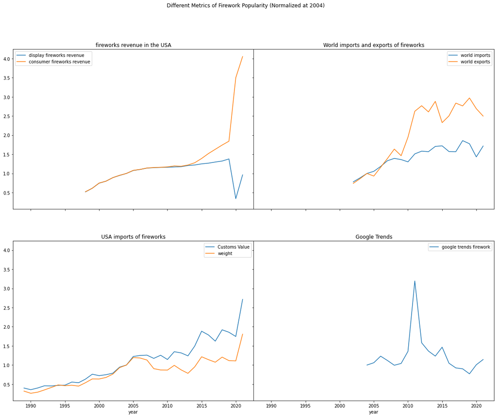

```python
# fireworks revenue (USA)
revenue_2004 = revenue[revenue.year==2004]
norm_rev = revenue.copy()
norm_rev["display fireworks revenue"] = revenue["display fireworks revenue"]/revenue_2004["display fireworks revenue"].iloc[0]
norm_rev["consumer fireworks revenue"] = revenue["consumer fireworks revenue"]/revenue_2004["consumer fireworks revenue"].iloc[0]

# worldwide imports
i_2004 = firework_imports[firework_imports.year==2004].World.iloc[0]
norm_import = firework_imports[["year", "World"]].copy()
norm_import.World = norm_import.World/i_2004
# worldwide exports
e_2004 = firework_exports[firework_exports.year==2004].World.iloc[0]
norm_export = firework_exports[["year", "World"]].copy()
norm_export.World = norm_export.World/e_2004
# merge the worldwides
norm_world = norm_import.merge(norm_export, how='outer', on='year')
norm_world.columns = ['year', 'world imports', 'world exports']

# USA imports
usa_2004 = imports_usa[imports_usa.year==2004]["Customs Value"].iloc[0]
norm_usa = imports_usa.copy()
norm_usa["Customs Value"] = norm_usa["Customs Value"]/usa_2004

usa_kg_2004 = imports_usa_kg[imports_usa_kg.year==2004]["weight"].iloc[0]
norm_usa_kg = imports_usa_kg.copy()
norm_usa_kg["weight"] = norm_usa_kg["weight"]/usa_kg_2004

norm_us = norm_usa.merge(norm_usa_kg, on='year', how='outer')

# Google Trends
google_trends_yr = google_trends.groupby(google_trends.date.dt.year)[["firework"]].sum() # groupby year
google_trends_yr.firework = google_trends_yr.firework/google_trends_yr.firework.loc[2004]
google_trends_yr = google_trends_yr.reset_index()
google_trends_yr.columns = ['year','google trends firework']

nrow = 2
ncol = 2
fig = plt.figure(figsize=(20,15))
gs = fig.add_gridspec(nrow, ncol, hspace=0.2, wspace=0)
axes = gs.subplots(sharex=True, sharey=True)

df_list = [norm_rev, norm_world, norm_us, google_trends_yr]
titles = ["fireworks revenue in the USA", "World imports and exports of fireworks", "USA imports of fireworks", "Google Trends"]

count=0
for r in range(nrow):
    for c in range(ncol):
        data=df_list[count].set_index("year")
        data.plot(ax=axes[r,c])
        axes[r,c].set_title (titles[count])
        count+=1

plt.suptitle("Different Metrics of Firework Popularity (Normalized at 2004)")
plt.show()
```

We can see that across multiple metrics the popularity of fireworks over time has been **slowly but consistently increasing**, with the notable exception of Google Trends. We also see that in terms of revenue, the COVID years caused a spike in revenue for consumer fireworks and a dip for display fireworks, which will be further investigated in Question 4.

### Question 2: When in the year are fireworks popular?

For this question we can only use the Google Trends data, which sorts data by the week

We then make a heatmap with week against year, seeing which weeks are the most popular for fireworks.

Note that the "weeks" represents how many multiples of 7s there are since the start of the year, rather than the more convential week based on Sunday

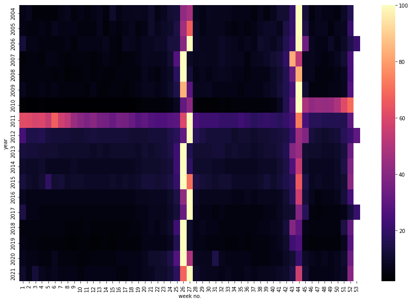

```python
fig = plt.figure(figsize=(15,10))
gt = google_trends.copy()
gt["year"] = gt["date"].dt.year
gt["week"] = (gt["date"].dt.dayofyear - 1) // 7 + 1
gt_pivot = gt.pivot(index='year', columns='week', values='firework')
heatmap = sns.heatmap(gt_pivot, cmap="magma")
heatmap.set_xlabel("week no.")
plt.show()
```

We can see that fireworks are very popular around weeks 25 - 27, which correspond to the 4th of July celebration in the United States.

We also see that fireworks experience another surge in popularity in week 43 and 44, likley corresponding to Deepavali, or Thanksgiving.

It is harder to see this, but near the end of the heatmap, on the last week of the year, fireworks experiences yet another surge in popularity due to the New Year Celebrations.

Less relevant to the findings, but we can see that the unusual activity from late 2010 to 2011 was caused by the song "Firework" being released by Katy Perry.

We can also plot a heatmap for injuries as those should correlate with **real** firework usage (in the USA):

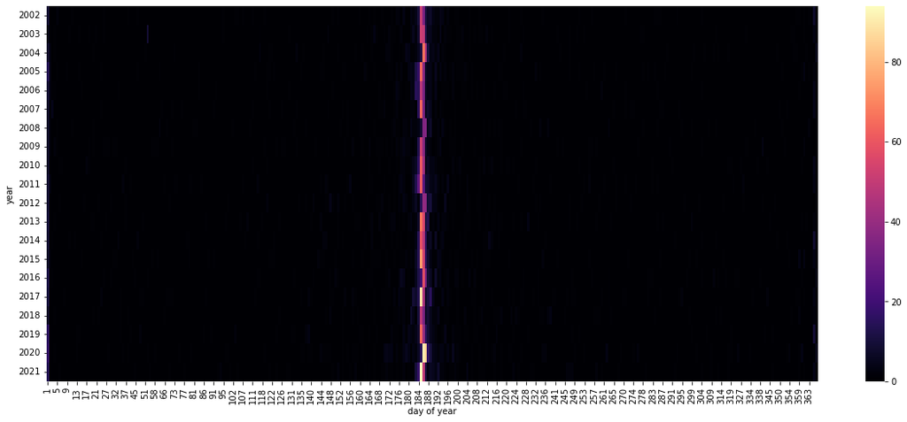

```python
neiss_date = NEISS_df.copy()
neiss_date["day"] = neiss_date["Treatment_Date"].dt.dayofyear
neiss_date["year"]= neiss_date["Treatment_Date"].dt.year
neiss_date_pivot = pd.pivot_table(neiss_date, index='year', columns='day', values='CPSC_Case_Number', aggfunc='count')
neiss_date_pivot = neiss_date_pivot.fillna(0)

plt.figure(figsize=(20,8))
heatmap = sns.heatmap(neiss_date_pivot, cmap="magma")
heatmap.set_xlabel("day of year")
plt.show()
```

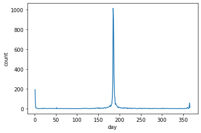

```python
neiss_date_agg = neiss_date_pivot.sum().to_frame()
neiss_date_agg = neiss_date_agg.reset_index()
neiss_date_agg.columns = ['day','count']
sns.lineplot(data=neiss_date_agg, x='day',y='count')
```

It is blindingly obvious that there is a huge spike of firework-related injuries (and hence firework popularity) during the 4th of July. We can see that there is another peak at the ends - which corresponds to the new year's celebration, although it is still behind the 4th of jul. In order to get a more informative heatmap we take the natural log of the data+1:

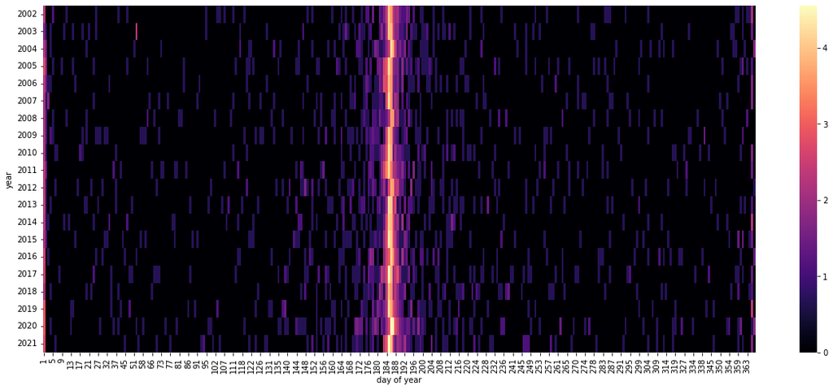

```python
neiss_date_log = np.log(neiss_date_pivot+1)
plt.figure(figsize=(20,8))
heatmap = sns.heatmap(neiss_date_log, cmap="magma")
heatmap.set_xlabel("day of year")
plt.show()
```

The heatmap looks much noisier but now we can also see that firework injuries are still much more common leading up to and after the 4th of july compared to the rest of the year. We can also see the new year's day spike near the edges

### Question 3: Has the rate of fireworks injuries increased or decreased over time?

Currently I only have data for the USA so this question is really more "Has the rate of firework injuries increased or decreased over time *in America*"

I have two sources, the annual fireworks report which estimates the true value and the direct NEISS data, which is a sample of the data available

I did a similar thing in Q1 where I normalized them at year 2002 and see the overall trend from the year 2002

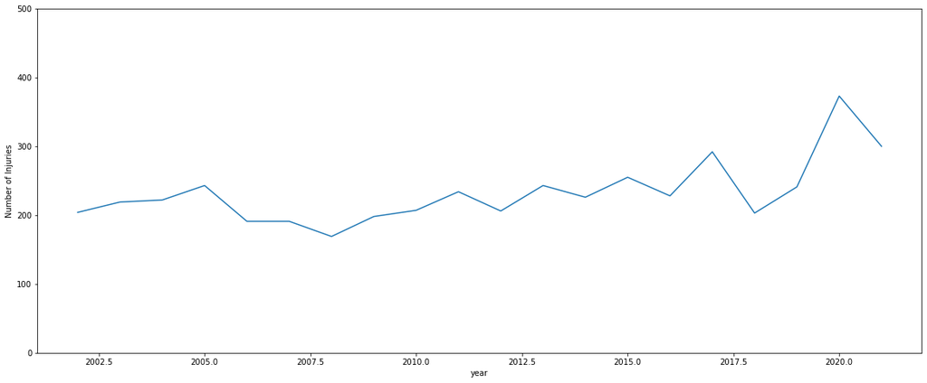

```python
NEISS_injuries_by_year = NEISS_df.groupby('year')[['CPSC_Case_Number']].count().reset_index(drop=False).rename(columns={'CPSC_Case_Number':'Number of Injuries'})

plt.figure(figsize=(20,8))
sns.lineplot(x="year", y="Number of Injuries", data=NEISS_injuries_by_year)
plt.ylim(0, 500)
plt.show()
```

However this does not take into account population increase. Let's take that into account:

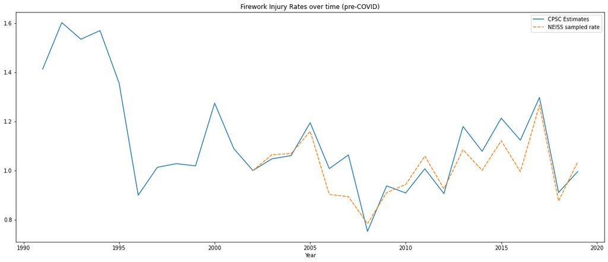

```python
# use NEISS counts
us_population = t1980_2021[t1980_2021.year>2001].reset_index(drop=True).us_population
NEISS_injuries_by_year['Injury rate'] = NEISS_injuries_by_year['Number of Injuries'].divide(us_population)
norm_const = NEISS_injuries_by_year[NEISS_injuries_by_year.year==2002]['Injury rate'].iloc[0]
NEISS_injuries_by_year['Injury rate'] = NEISS_injuries_by_year['Injury rate']/norm_const

# use CPSC estimates
us_population = t1980_2021[t1980_2021.year>=1991].reset_index(drop=True).us_population
est_injuries = firework_estimated_injuries.copy()
est_injuries['Estimated Injuries'] = est_injuries['Estimated Injuries'].divide(us_population)
norm_const = est_injuries[est_injuries.Year==2002]['Estimated Injuries'].iloc[0]
est_injuries['Estimated Injuries'] = est_injuries['Estimated Injuries']/norm_const

combined = NEISS_injuries_by_year.merge(est_injuries, left_on='year', right_on='Year', how='outer')
combined = combined[["Year", "Estimated Injuries", "Injury rate"]].copy().set_index('Year')
combined = combined.rename(columns={'Injury rate':'NEISS sampled rate', 'Estimated Injuries':'CPSC Estimates'})
combined = combined[combined.index<2020]


plt.figure(figsize=(20,8))
sns.lineplot(data=combined)
plt.title("Firework Injury Rates over time (pre-COVID)")
plt.show()
```

It does not seem like a clear trend. We do not include the covid years (2020-2021) as that will be investigated in a later question. We can find out if this trend is statistically significant or not:

```python
est_injuries_pre_covid = firework_estimated_injuries[firework_estimated_injuries.Year<2020]
pearson_coef, p_value = stats.pearsonr(est_injuries_pre_covid['Year'], est_injuries_pre_covid['Estimated Injuries'])
print(f"CPSC estimates: R²: {pearson_coef**2}, p-value: {p_value}")

neiss_injuries_pre_covid = NEISS_injuries_by_year[NEISS_injuries_by_year.year<2020]
pearson_coef, p_value = stats.pearsonr(neiss_injuries_pre_covid['year'], neiss_injuries_pre_covid['Injury rate'])
print(f"NEISS injuries: R²: {pearson_coef**2}, p-value: {p_value}")
```

```
CPSC estimates: R²: 0.0007937147867804917, p-value: 0.8846549039632713
NEISS injuries: R²: 0.019112301950937594, p-value: 0.584334810683719
```

Since `R²<0.65` and `p-value>=0.05` for both, the trend of increase (or any trend for that matter) is not statistically significant, so we can conclude that firework injuries have not increased or decreased in any way (pre-covid)

### Question 3: Breaking down Injury statistics

For this, NEISS data is used. Let's start with Age:

#### By Age

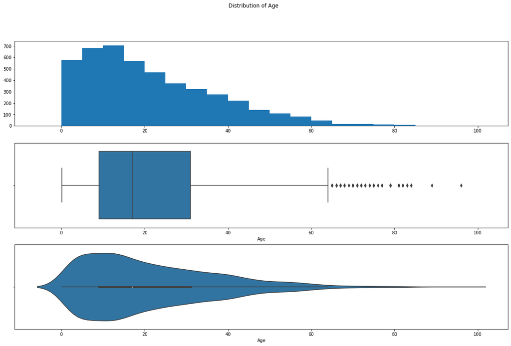

```python
nrow=3
ncol=1

fig = plt.figure(figsize=(20,12))
gs = fig.add_gridspec(nrow, ncol, hspace=0.2, wspace=0)
axes = gs.subplots(sharex=True, sharey=False)

neiss_age = NEISS_df.copy()[["CPSC_Case_Number", "Age"]]
neiss_age = neiss_age[neiss_age.Age!=0] # remove entries with age not recorded

def filter_out_200s(x):
    if x>=200:
        return (x-200)/12.0 # Age>200 are actually patients under 2 years old
    return x

neiss_age.Age = neiss_age.Age.apply(filter_out_200s).copy()
max_age = neiss_age.Age.max()

bins = [x for x in range(0,86,5)]
widths = [5 for i in range(17)] + [max_age - 85]

weights = [neiss_age[(neiss_age.Age<5)|(neiss_age.Age>=200)].CPSC_Case_Number.count()]
for i in range(5,85,5):
    weights.append(neiss_age[(neiss_age.Age>=i)&(neiss_age.Age < i+5)].CPSC_Case_Number.count())
weights.append(neiss_age[(neiss_age.Age>=85)&(neiss_age.Age < max_age)].CPSC_Case_Number.count())

bar_axes = axes[0]
bar = bar_axes.bar(bins, weights, width=widths, align='edge')
fig.suptitle("Distribution of Age")
bar_axes.xaxis.set_tick_params(which='both', labelbottom=True)

box_axes = axes[1]
sns.boxplot(x=neiss_age.Age, ax=box_axes)
box_axes.xaxis.set_tick_params(which='both', labelbottom=True)

violin_axes = axes[2]
sns.violinplot(x=neiss_age.Age, ax=violin_axes)

plt.show()
```

```python
print(neiss_age[["Age"]].describe()[1:])
neiss_age["Age"].mode()
```

```
            Age
mean  21.346558
std   15.929530
min    0.083333
25%    9.000000
50%   17.000000
75%   31.000000
max   96.000000
```

```
0    12.0
Name: Age, dtype: float64
```

We see that the data is skewed to the right, and the largest age group that gets injured are those aged 10-15. The mode of age 12 is within the 10-15 age bracket. However, the median and mean age are significantly higher at 17 years old and 21.3 years old respectively. This suggests that it is mostly young children and teenagers that get injured by fireworks.

However, we have not accounted for the fact that different age brackets will have different population numbers. To do that, we adjust for population to get a sampled injury rate:

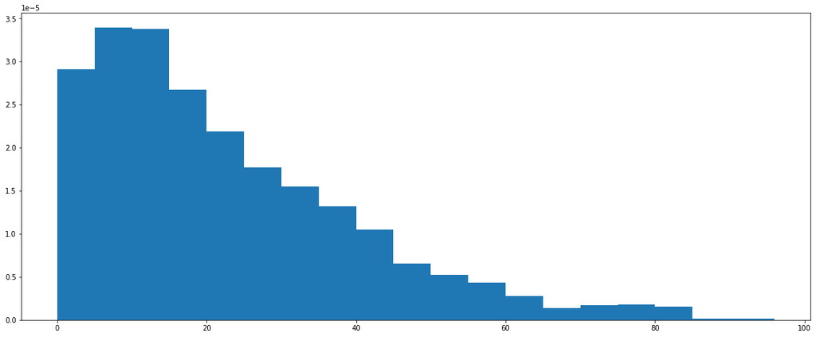

```python
# adjusted for population
us_pop_age_mean = t2000_2021.mean().to_frame().T[age_cols].T.iloc[:,0].reset_index(drop=True)
rate_byage = pd.Series(weights).divide(us_pop_age_mean)
rate_byage = pd.DataFrame(data={"age":age_cols, "rate":rate_byage})
fig = plt.figure(figsize=(20,8))
plt.bar(bins, rate_byage.rate, width=widths, align='edge')
plt.show()
```

Here we see that in terms of injury rates, it is 5-9 years olds who are most likely to end up in a hospital due to firework-related issues.

#### By Sex

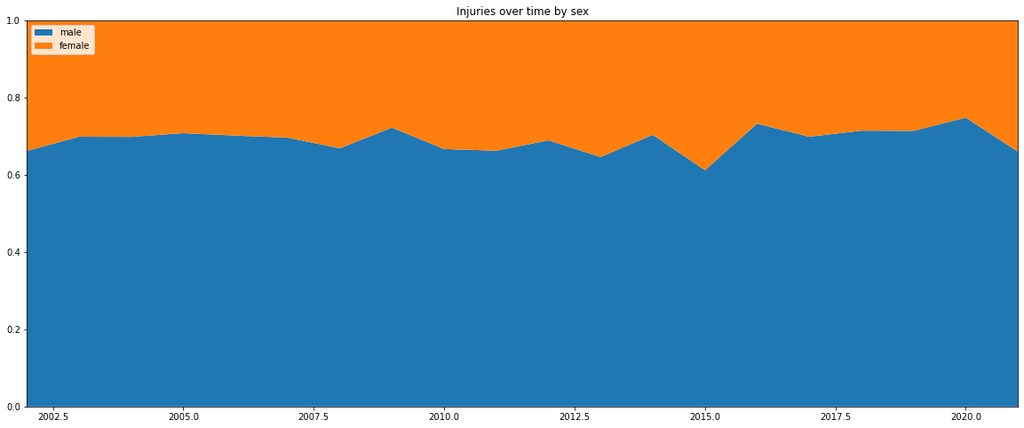

```python
neiss_sex = NEISS_df.groupby(["Sex","year"])[['CPSC_Case_Number']].count().reset_index()
neiss_sex = neiss_sex.pivot(index='year', columns='Sex')
neiss_sex.columns = ['male','female']
plt.figure(figsize=(20,8))
neiss_sex_perc = neiss_sex.divide(neiss_sex.sum(axis=1), axis=0)
plt.stackplot(range(2002,2022),  neiss_sex_perc["male"],  neiss_sex_perc["female"], labels=['male','female'])
plt.legend(loc='upper left')
plt.margins(0,0)
plt.title('Injuries over time by sex')
plt.show()
```

As we can see the gender ratio in terms of injuries is nearly constant. To see the gender ratio, we plot a pie chart:

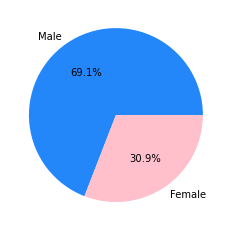

```python
neiss_sex2 = NEISS_df.groupby("Sex")['CPSC_Case_Number'].count()
plt.pie(
    neiss_sex2,
    shadow=False,
    colors=['#2386f9', 'Pink'],
    startangle=0,
    autopct='%1.1f%%',
    labels=['Male','Female']
)
plt.show()
```

We see that about 7 in 10 firework injuries are by males.

#### By Race

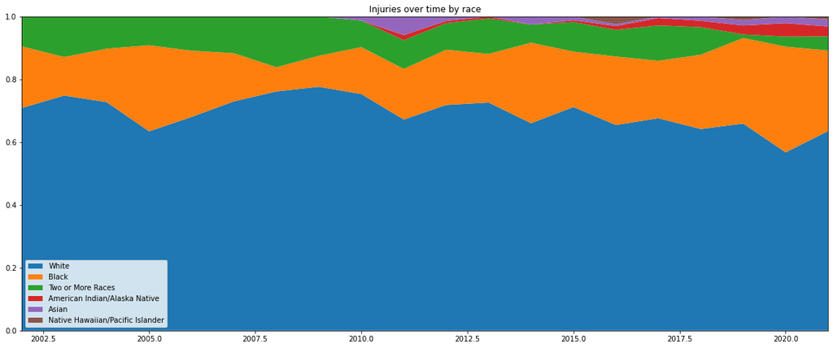

```python
neiss_race = NEISS_df[NEISS_df.Race!=0].groupby(["Race","year"])[['CPSC_Case_Number']].count().reset_index()
neiss_race = neiss_race.pivot(index='year', columns='Race').fillna(0)
neiss_race.columns=['White','Black','Two or More Races','AIAN','Asian','NHPI']
plt.figure(figsize=(20,8))
neiss_race_perc = neiss_race.divide(neiss_race.sum(axis=1), axis=0)
plt.stackplot(range(2002,2022),
              neiss_race_perc["White"],
              neiss_race_perc["Black"],
              neiss_race_perc['Two or More Races'],
              neiss_race_perc['AIAN'],
              neiss_race_perc['Asian'],
              neiss_race_perc['NHPI'],
              labels=['White','Black','Two or More Races','American Indian/Alaska Native','Asian','Native Hawaiian/Pacific Islander'])
plt.legend(loc='lower left')
plt.margins(0,0)
plt.title('Injuries over time by race')
plt.show()
```

We see that the ratio of injuries remains fairly constant. To see the exact percentages, we plot a pie chart:

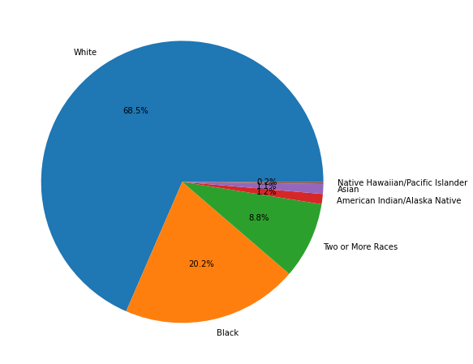

```python
races=['White','Black','Two or More Races','American Indian/Alaska Native','Asian','Native Hawaiian/Pacific Islander']
neiss_race2 = NEISS_df[NEISS_df.Race!=0] # remove those with unspecified race
neiss_race2 = neiss_race2.groupby("Race")['CPSC_Case_Number'].count()
plt.figure(figsize=(20,8))
plt.pie(
    neiss_race2,
    shadow=False,
    colors=['#1F77B4', '#FF7F0E', "#2CA02C", "#D62728", "#9467BD", "#8C564B"],
    autopct='%1.1f%%',
    labels=races
)
plt.show()
```

We can adjust this by population:

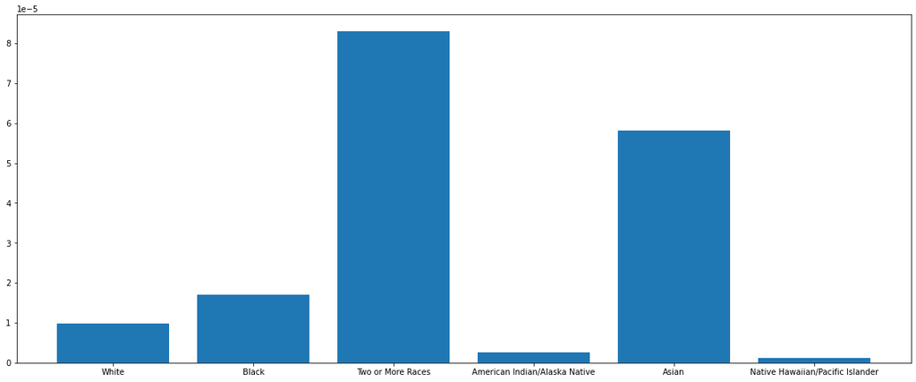

```python
neiss_race_adj = neiss_race2.reset_index(drop=True).divide(t2000_2021[race_cols].mean().reset_index(drop=True))
plt.figure(figsize=(20,8))
plt.bar(x=[x for x in range(0,6)], height=neiss_race_adj, tick_label=races)
plt.show()
```

### by Body Part

```python
body_parts = NEISS_df[NEISS_df.Body_Part!=87] # remove entries that are not recorded
body_parts = NEISS_df.groupby('Body_Part')[['CPSC_Case_Number']].count()
body_parts.columns = ['count']
body_parts = body_parts.reset_index().sort_values(by='count',ascending=False)
body_parts
```

|  | Body_Part | count |
| --- | --- | --- |
| 16 | 82 | 929 |
| 12 | 77 | 845 |
| 23 | 92 | 528 |
| 11 | 76 | 524 |
| 17 | 83 | 188 |
| 2 | 31 | 184 |
| 7 | 36 | 183 |
| 15 | 81 | 152 |
| 10 | 75 | 147 |
| 4 | 33 | 135 |
| 13 | 79 | 128 |
| 25 | 94 | 106 |
| 19 | 85 | 98 |
| 8 | 37 | 80 |
| 22 | 89 | 77 |
| 14 | 80 | 55 |
| 21 | 88 | 50 |
| 6 | 35 | 48 |
| 1 | 30 | 45 |
| 5 | 34 | 41 |
| 24 | 93 | 32 |
| 9 | 38 | 20 |
| 18 | 84 | 18 |
| 3 | 32 | 18 |
| 20 | 87 | 9 |
| 0 | 0 | 5 |

We see that the top 10 body parts injured are:

1. Hands
2. Eyeball
3. Finger
4. Face
5. Foot
6. Trunk (Upper)
7. Leg (Lower)
8. Leg (Upper)
9. Head
10. Arm (Lower, not including elbow or wrist)

However this data is not very useful, so let's divide it into several categories:

1. Arm/Shoulder
2. Eye
3. Hand/Finger
4. Head/Face/Ear
5. Leg
6. Trunk
7. Others

[figure not shown]

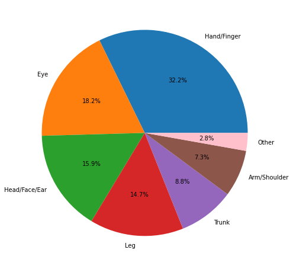

```python
def categorize_body_part(x):
    if(x in [30, 33, 80, 94]):
        return "Arm/Shoulder"
    if(x in [77]):
        return "Eye"
    if(x in [34, 82, 92]):
        return "Hand/Finger"
    if(x in [32, 75, 76, 88]):
        return "Head/Face/Ear"
    if(x in [35, 36, 37, 81, 83, 93]):
        return "Leg"
    if(x in [31, 38, 79, 89]):
        return "Trunk"
    return "Other"
body_parts["body_region"] = body_parts.Body_Part.apply(categorize_body_part)
body_parts = body_parts.groupby("body_region")["count"].sum()
body_parts = body_parts.sort_values(ascending=False)
plt.figure(figsize=(20,8))
plt.pie(
    body_parts,
    shadow=False,
    colors=['#1F77B4', '#FF7F0E', "#2CA02C", "#D62728", "#9467BD", "#8C564B", "Pink"],
    startangle=0,
    autopct='%1.1f%%',
    labels=body_parts.index
)
plt.show()
```

We see that Hand/Fingers are the most common type of injury, followed by those to the eye, then those to the Head/Face/Ear.

### Question 4: Has the pandemic affected sales of fireworks and injury rate of fireworks as professional events were cancelled?

Lets first investigate the injury rate of fireworks.

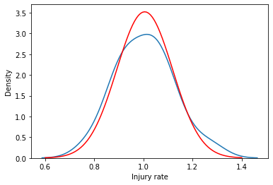

```python
neiss_injury_rate = neiss_injuries_pre_covid["Injury rate"]
mean, var  = stats.distributions.norm.fit(neiss_injury_rate)
x = np.linspace(0.6,1.4,100)

fitted_neiss_injury_rate = stats.distributions.norm.pdf(x, mean, var)
sns.kdeplot(neiss_injury_rate)
plt.plot(x,fitted_neiss_injury_rate,'r-')
plt.show()
```

```python
covid_neiss_injury_rate = NEISS_injuries_by_year[NEISS_injuries_by_year.year == 2020]["Injury rate"].iloc[0]
stats.distributions.norm.pdf(covid_neiss_injury_rate, mean, var)
```

```
6.853711661250975e-06
```

Next let's investigate the revenue. However since the revenue has an increasing trend, we first have to make a linear regression model. Starting with fireworks revenue in the US:

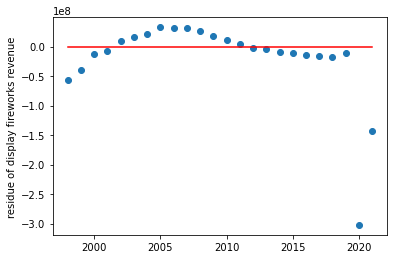

```python
lm = LinearRegression()
revenue_precovid = revenue[revenue.year<2020]
ŷ = lm.fit(revenue_precovid[["year"]], revenue_precovid["display fireworks revenue"])
ŷ = lm.predict(revenue[['year']])
e = revenue['display fireworks revenue'] - ŷ # residue
plt.plot(revenue.year, e, 'o')
plt.plot([1998,2021], [0,0], color="red")
plt.ylabel("residue of display fireworks revenue")
plt.show()
```

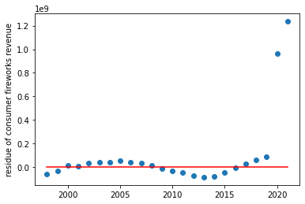

```python
lm = LinearRegression()
revenue_precovid = revenue[revenue.year<2020]
ŷ = lm.fit(revenue_precovid[["year"]], revenue_precovid["consumer fireworks revenue"])
ŷ = lm.predict(revenue[['year']])
e = revenue['consumer fireworks revenue'] - ŷ # residue
plt.plot(revenue.year, e, 'o')
plt.plot([1998,2021], [0,0], color="red")
plt.ylabel("residue of consumer fireworks revenue")
plt.show()
```

As we can see, that is a huge decrease in display fireworks revenue in 2020 and 2021, especialy 2020. The opposite is true for consumer fireworks revenue - it skyrocketed up in 2020, and further increased in 2021.

# Results Findings & Conclusion

For each research question, summarize in 2-3 visualizations which will answer the question. Intrepret the results accordingly and give your observation and conclusion. The visualizations should be well presented (apply what you have learnt in Chapter 9 on data communication). The plots shown here could be an enhanced version of the EDA plots, or presented in another format.

### Question 1: Has the popularity of fireworks increased or decreased over time?

It has increased, across several metrics:

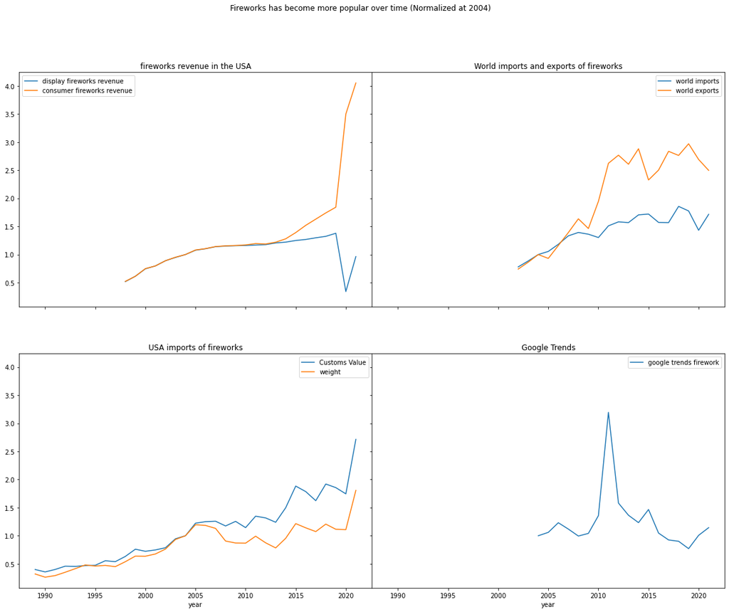

```python
nrow = 2
ncol = 2
fig = plt.figure(figsize=(20,15))
gs = fig.add_gridspec(nrow, ncol, hspace=0.2, wspace=0)
axes = gs.subplots(sharex=True, sharey=True)
count=0

for r in range(nrow):
    for c in range(ncol):
        data=df_list[count].set_index("year")
        data.plot(ax=axes[r,c])
        axes[r,c].set_title (titles[count])
        count+=1

plt.suptitle("Fireworks has become more popular over time (Normalized at 2004)")
plt.show()
```

In addition, we can see that due to COVID, **consumer** firework revenue skyrocketed while **display** firework revenue plummeted, then partially recovered. This is likely because due to COVID-19-related measures, many display firework events were cancelled causing display fireworks revenue to plummet.

### Question 2: When in the year are fireworks most popular?

Mainly festive holidays, especially the 4th of July and Deepavali/Diwali:

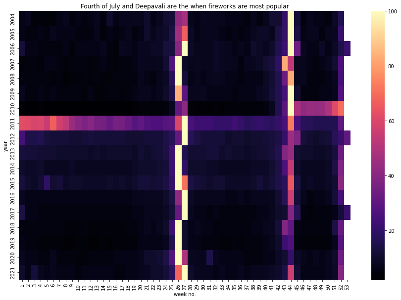

```python
fig = plt.figure(figsize=(15,10))
gt = google_trends.copy()
gt["year"] = gt["date"].dt.year
gt["week"] = (gt["date"].dt.dayofyear - 1) // 7 + 1
gt_pivot = gt.pivot(index='year', columns='week', values='firework')
heatmap = sns.heatmap(gt_pivot, cmap="magma")
heatmap.set_xlabel("week no.")
plt.title("Fourth of July and Deepavali are the when fireworks are most popular")
plt.show()
```

We can see that fireworks are very popular around weeks 25 - 27, which correspond to the 4th of July celebration in the United States.

We also see that fireworks experience another surge in popularity in week 43 and 44, likley corresponding to Deepavali, or Thanksgiving.

It is harder to see this, but near the end of the heatmap, on the last week of the year, fireworks experiences yet another surge in popularity due to the New Year Celebrations.

Less relevant to the findings, but we can see that the unusual activity from late 2010 to 2011 was caused by the song "Firework" being released by Katy Perry.

Using injuries from NEISS, we can find the **real** firework usage as the injuries should correlate with usage (in the USA):

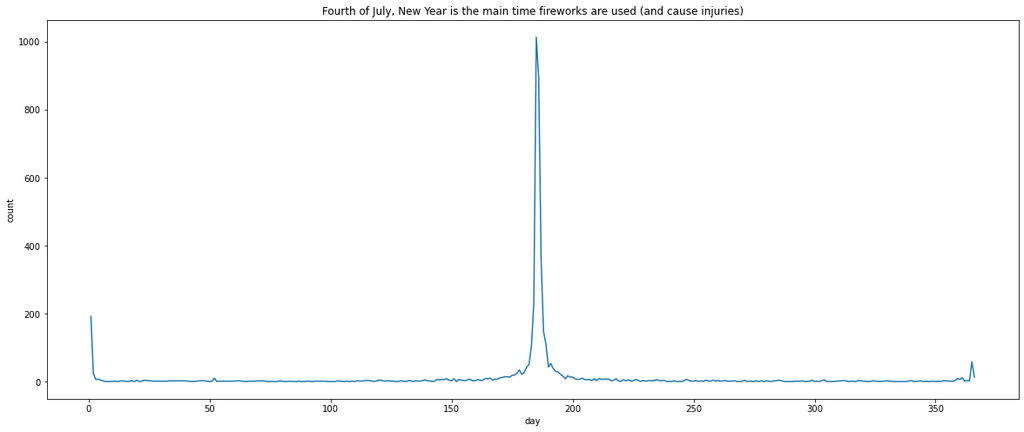

```python
neiss_date_agg = neiss_date_pivot.sum().to_frame()
neiss_date_agg = neiss_date_agg.reset_index()
neiss_date_agg.columns = ['day','count']
plt.figure(figsize=(20,8))
sns.lineplot(data=neiss_date_agg, x='day',y='count')
plt.title("Fourth of July, New Year is the main time fireworks are used (and cause injuries)")
plt.show()
```

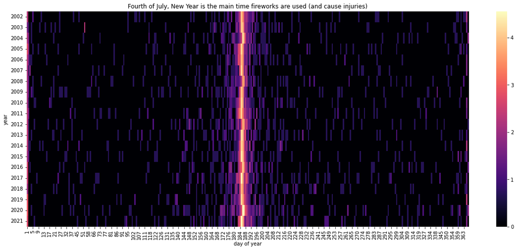

```python
neiss_date_log = np.log(neiss_date_pivot+1)
plt.figure(figsize=(20,8))
heatmap = sns.heatmap(neiss_date_log, cmap="magma")
heatmap.set_xlabel("day of year")
plt.title("Fourth of July, New Year is the main time fireworks are used (and cause injuries)")
plt.show()
```

It is blindingly obvious that there is a huge spike of firework-related injuries (and hence firework popularity) during the 4th of July. We can see that there is another peak at the ends - which corresponds to the new year's celebration, although it is still behind the 4th of july in terms of injuries (and hence popularity).

We can also see from the logarithmic heatmap that injuries are more common leading up to and after the fourth of july celebrations, as compared to the rest of the year.

### Question 3: Has the rate of fireworks injuries increased or decreased over time?

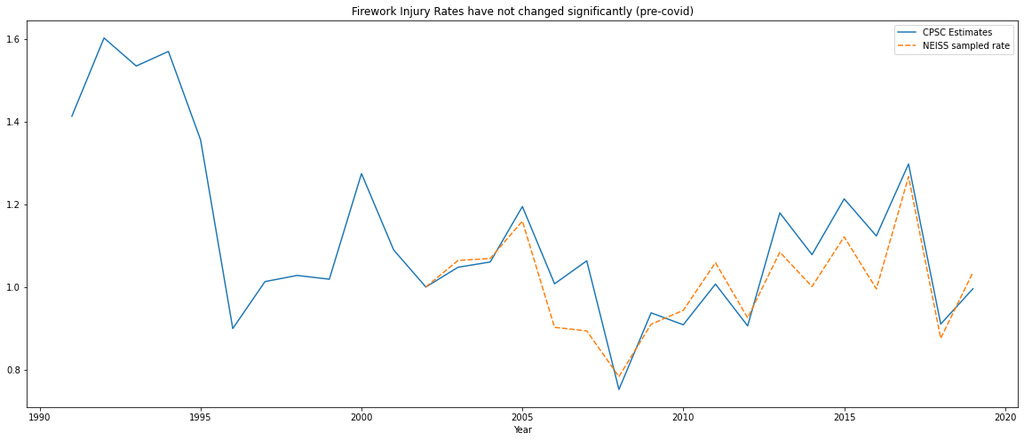

```python
plt.figure(figsize=(20,8))
sns.lineplot(data=combined)
plt.title("Firework Injury Rates have not changed significantly (pre-covid)")
plt.show()
```

the p-value from the pearson for both CPSC Estimates and the NEISS sampled rate are both far above 5%, hence we can conclude that any increase/decrease in injury rates is **not statistically significant**

### Question 4 (i): Breaking down Fireworks-Related Injuries by Age

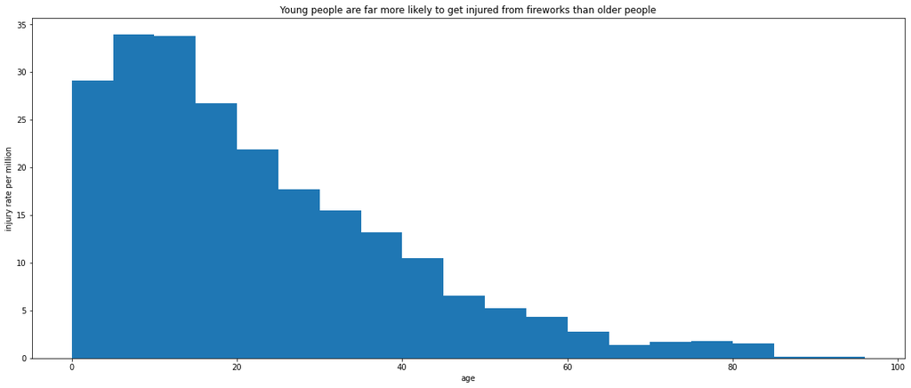

```python
us_pop_age_mean = t2000_2021.mean().to_frame().T[age_cols].T.iloc[:,0].reset_index(drop=True)
rate_byage = pd.Series(weights).divide(us_pop_age_mean) * 1e6
rate_byage = pd.DataFrame(data={"age":age_cols, "rate":rate_byage})
fig = plt.figure(figsize=(20,8))
plt.bar(bins, rate_byage.rate, width=widths, align='edge')
plt.xlabel("age")
plt.ylabel("injury rate per million")
plt.title("Young people are far more likely to get injured from fireworks than older people")
plt.show()
```

Here we see that in terms of injury rates, it is 5-9 years olds who are most likely to end up in a hospital due to firework-related issues, followed by those aged 10-14, then followed by ages 0-4. From then on, the older you are, the less likely you are to get injured from a firework.

### Question 4 (ii): Breaking down Fireworks-Related Injuries by Sex

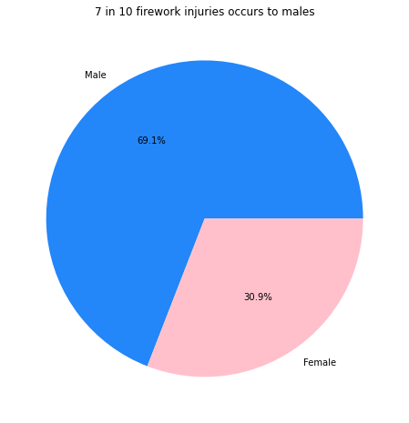

```python
neiss_sex2 = NEISS_df.groupby("Sex")['CPSC_Case_Number'].count()
plt.figure(figsize=(20,8))
plt.pie(
    neiss_sex2,
    shadow=False,
    colors=['#2386f9', 'Pink'],
    startangle=0,
    autopct='%1.1f%%',
    labels=['Male','Female']
)
plt.title("7 in 10 firework injuries occurs to males")
plt.show()
```

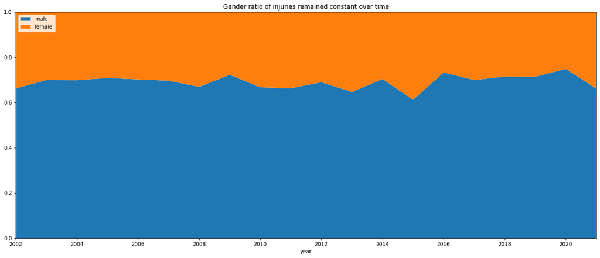

```python
neiss_sex = NEISS_df.groupby(["Sex","year"])[['CPSC_Case_Number']].count().reset_index()
neiss_sex = neiss_sex.pivot(index='year', columns='Sex')
neiss_sex.columns = ['male','female']
plt.figure(figsize=(20,8))
neiss_sex_perc = neiss_sex.divide(neiss_sex.sum(axis=1), axis=0)
plt.stackplot(pd.to_datetime(neiss_sex_perc.reset_index()['year'], format="%Y"),  neiss_sex_perc["male"],  neiss_sex_perc["female"], labels=['male','female'])
plt.legend(loc='upper left')
plt.margins(0,0)
plt.title('Gender ratio of injuries remained constant over time')
plt.xlabel("year")
plt.show()
```

From this, we see that 7 in 10 firework injuries happen to males, compared to about 3 in 10 for females, and this has remained constant over time, from 2002 all the way until 2021.

### Question 4 (iii): Breaking down Fireworks-Related Injuries by Race

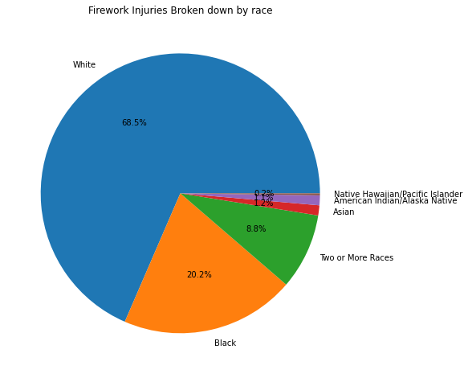

```python
races=['White','Black','Two or More Races','Asian','American Indian/Alaska Native','Native Hawaiian/Pacific Islander']
neiss_race = NEISS_df[NEISS_df.Race!=0] # remove those with unspecified race
neiss_race = neiss_race.groupby("Race")['CPSC_Case_Number'].count()
plt.figure(figsize=(20,8))
plt.pie(
    neiss_race,
    shadow=False,
    colors=['#1F77B4', '#FF7F0E', "#2CA02C", "#D62728", "#9467BD", "#8C564B"],
    autopct='%1.1f%%',
    labels=races
)
plt.title('Firework Injuries Broken down by race')
plt.show()
```

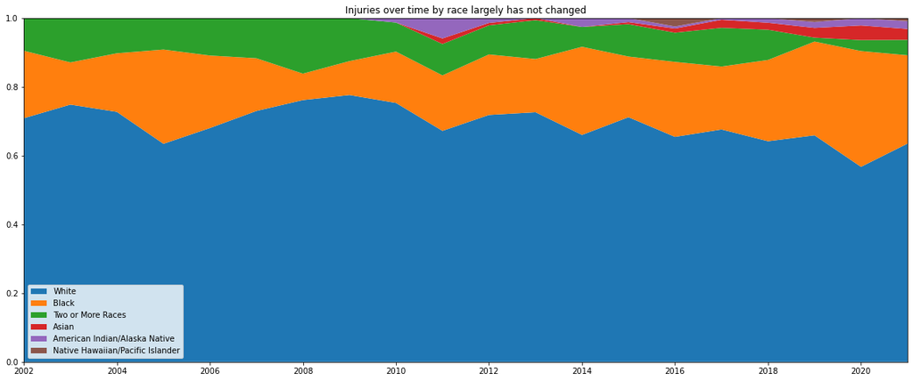

```python
neiss_race2 = NEISS_df[NEISS_df.Race!=0].groupby(["Race","year"])[['CPSC_Case_Number']].count().reset_index()
neiss_race2 = neiss_race2.pivot(index='year', columns='Race').fillna(0)
neiss_race2.columns=['White','Black','Two or More Races','Asian','AIAN','NHPI']
plt.figure(figsize=(20,8))
neiss_race_perc = neiss_race2.divide(neiss_race2.sum(axis=1), axis=0)
plt.stackplot(pd.to_datetime(neiss_race_perc.reset_index()['year'], format="%Y"),
              neiss_race_perc["White"],
              neiss_race_perc["Black"],
              neiss_race_perc['Two or More Races'],
              neiss_race_perc['Asian'],
              neiss_race_perc['AIAN'],
              neiss_race_perc['NHPI'],
              labels=['White','Black','Two or More Races','Asian','American Indian/Alaska Native','Native Hawaiian/Pacific Islander'])
plt.legend(loc='lower left')
plt.margins(0,0)
plt.title('Injuries over time by race largely has not changed')
plt.show()
```

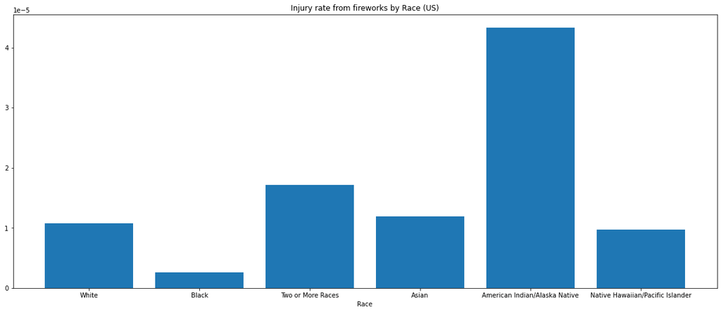

```python
neiss_race3 = NEISS_df[NEISS_df.Race!=0] # remove those with unspecified race
neiss_race3 = neiss_race3.groupby("Race")['CPSC_Case_Number'].count()
neiss_race3 = neiss_race3.rename({1:"White",2:"Black",3:"Two or More Races",4:"Asian",5:"AIAN",6:"NHPI"})
neiss_race_adj = neiss_race3.divide(t2000_2021[race_cols].mean())
plt.figure(figsize=(20,8))
plt.bar(x=[x for x in range(0,6)], height=neiss_race_adj, tick_label=races)
plt.title("Injury rate from fireworks by Race (US)")
plt.xlabel("Race")
plt.show()
```

While in the above pie chart we see that 68% or almost 7 in 10 firework injuries happen to White people (in the USA), we see that in terms of injury rates, it is American Indians/Alaskan Natives which more likely to get injured from fireworks than other races, followed by those with two or more races. Blacks have the least injuries.

In addition, we see that the overall racial ratio for fireworks injuries has not changed significantly.

### Question 4 (iv): Breaking down Fireworks-Related Injuries by Body Part

we first divide the body parts it into several categories:

1. Arm/Shoulder
2. Eye
3. Hand/Finger
4. Head/Face/Ear
5. Leg
6. Trunk
7. Others

[figure not shown]

We can then analyze it by body *region*

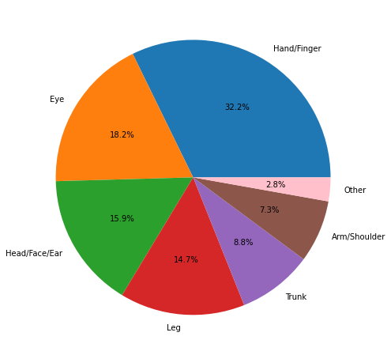

```python
body_parts = NEISS_df[NEISS_df.Body_Part!=87] # remove entries that are not recorded
body_parts = NEISS_df.groupby('Body_Part')[['CPSC_Case_Number']].count()
body_parts.columns = ['count']
body_parts = body_parts.reset_index().sort_values(by='count',ascending=False)

def categorize_body_part(x):
    if(x in [30, 33, 80, 94]):
        return "Arm/Shoulder"
    if(x in [77]):
        return "Eye"
    if(x in [34, 82, 92]):
        return "Hand/Finger"
    if(x in [32, 75, 76, 88]):
        return "Head/Face/Ear"
    if(x in [35, 36, 37, 81, 83, 93]):
        return "Leg"
    if(x in [31, 38, 79, 89]):
        return "Trunk"
    return "Other"
body_parts["body_region"] = body_parts.Body_Part.apply(categorize_body_part)
body_parts = body_parts.groupby("body_region")["count"].sum()
body_parts = body_parts.sort_values(ascending=False)
plt.figure(figsize=(20,8))
plt.pie(
    body_parts,
    shadow=False,
    colors=['#1F77B4', '#FF7F0E', "#2CA02C", "#D62728", "#9467BD", "#8C564B", "Pink"],
    startangle=0,
    autopct='%1.1f%%',
    labels=body_parts.index
)
plt.show()
```

We see that Hand/Fingers are the most common type of injury, followed by those to the eye, then those to the Head/Face/Ear. about 1/3 of all firework related injuries are those to the hand/finger, which makes sense especially since when a firework is mishandled or malfunctioning, the patient was probably holding it in his hand or touching it. The large Eye sector could be a bias - not all hand injuries need or necessitate hospital care; but eye injuries almost always necessitate a visit. A similar situation could be ongoing for the the Head/Face/Ear category.

### Question 4: Has the pandemic affected sales of fireworks and injury rate of fireworks as professional events were cancelled?

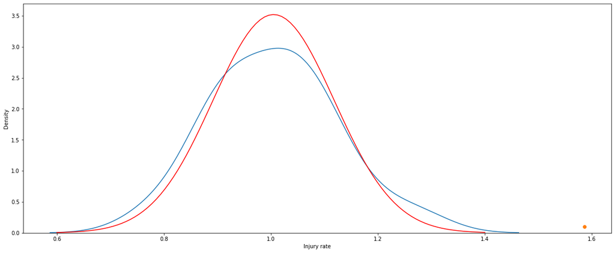

```python
neiss_injury_rate = neiss_injuries_pre_covid["Injury rate"]
mean, var  = stats.distributions.norm.fit(neiss_injury_rate)
x = np.linspace(0.6,1.4,100)

fitted_neiss_injury_rate = stats.distributions.norm.pdf(x, mean, var)
plt.figure(figsize=(20,8))
sns.kdeplot(neiss_injury_rate)
plt.plot(x,fitted_neiss_injury_rate,'r-')
covid = NEISS_injuries_by_year[NEISS_injuries_by_year.year == 2020]["Injury rate"].iloc[0]
plt.plot(covid, 0.1, 'o')
plt.show()
```

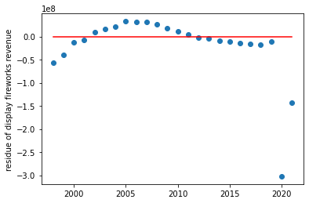

```python
lm = LinearRegression()
revenue_precovid = revenue[revenue.year<2020]
ŷ = lm.fit(revenue_precovid[["year"]], revenue_precovid["display fireworks revenue"])
ŷ = lm.predict(revenue[['year']])
e = revenue['display fireworks revenue'] - ŷ # residue
plt.plot(revenue.year, e, 'o')
plt.plot([1998,2021], [0,0], color="red")
plt.ylabel("residue of display fireworks revenue")
plt.show()
```

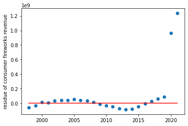

```python
lm = LinearRegression()
revenue_precovid = revenue[revenue.year<2020]
ŷ = lm.fit(revenue_precovid[["year"]], revenue_precovid["consumer fireworks revenue"])
ŷ = lm.predict(revenue[['year']])
e = revenue['consumer fireworks revenue'] - ŷ # residue
plt.plot(revenue.year, e, 'o')
plt.plot([1998,2021], [0,0], color="red")
plt.ylabel("residue of consumer fireworks revenue")
plt.show()
```

As we can see, that is a huge decrease in display fireworks revenue in 2020 and 2021, especialy 2020. The opposite is true for consumer fireworks revenue - it skyrocketed up in 2020, and further increased in 2021. Hence we can conclude that COVID 19 has affected the revenue of fieworks.

# Recommendations or Further Works

State any recommendations, improvements or further works.

### On Firework Injuries

I would recommend parents/guardians with children to take special care when using fireworks around children, or letting children view fireworks, as from the data, young children and tweens have the highest injury rate from fireworks.

Since fireworks, especially consumer fireworks are only really used on special occasions, depending on the cultures, extra care must be taken during those times to prevent injuries from occuring, and be wary of injuries to the eye.

Generally, display fireworks are less dangerous than self-lit fireworks so more care has to be taken for self-lit fireworks aka consumer fireworks.

### Further Works

There are many biases in this report, because a lot of the analysis relies on one data source, and hospital cases do not necessarily reflect injury rates. In addition, an analysis by firework device type would also be useful to know which fireworks are more dangerous than others.

# References

Cite any references made, and links where you obtained the data. You may wish to read about how to use markdown in Jupyter notebook to make your report easier to read. https://www.ibm.com/docs/en/db2-event-store/2.0.0?topic=notebooks-markdown-jupyter-cheatsheet

1. https://www.nfpa.org//-/media/Files/News-and-Research/Fire-statistics-and-reports/US-Fire-Problem/Fire-causes/osfireworkstables.pdf
2. https://theconversation.com/yes-fireworks-prices-are-skyrocketing-but-there-should-be-plenty-of-bottle-rockets-and-sparklers-for-you-and-your-family-this-fourth-of-july-185182
3. https://www.cpsc.gov/s3fs-public/2019-Fireworks-Annual-Report.pdf